# Creating Visualizations with ggplot

Benjamin Cassidy

1/27/2020

## Plots with ggplot2

We are going to make plots in R using the ggplot2 package from the tidyverse.

## Methods:

We will install these **packages**

- **tidyverse** : suite of packages for wrangling and viz with ggplot
- **readxl** : to read in Excels into R
- **here** : to help with filepath syntax

```r
library(tidyverse) # install.packages("tidyverse")
library(readxl) # install.packages("readxl")
library(here) # install.packages("here")
```

## Data:

Here we will read in the data from the **California National Parks** and **California Channel Islands** data sets

```r
ca_np <- read_csv(here("data/ca_np.csv"))
#alternative code -- omit 'here' but then will be filepath specific
#alternative code 2 -- nere("data","ca_np.csv")

ci_np <- read_xlsx(here("data/ci_np.xlsx"))
#alternative code -- call read_excel instead
```

## Visualization:

Using ggplot2 to make visualizaions from the data –

Makes these layer by layer to create a code layer and map them for repeatability.

Here are the steps: - Tell R you’re using ggplot - A: What data frame are you getting the variables from? - A: What variable(s) do you want to plot? - A: What type of graph do you want to make using (geom_)?

### Example of ggplot line plot for ci_np vistors X year

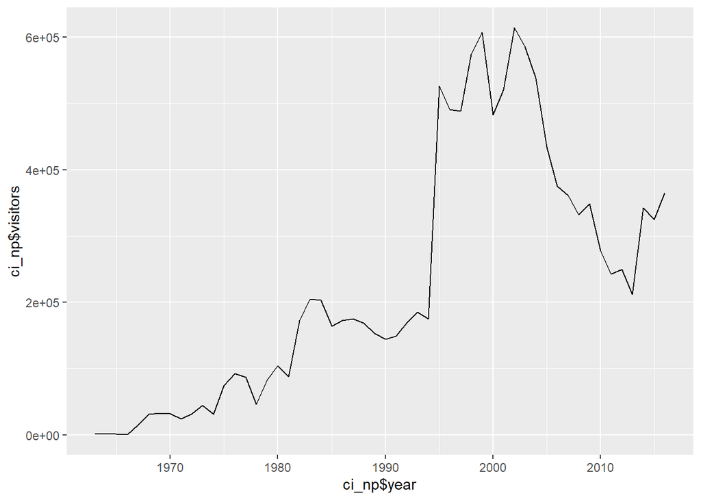

```r
# X == year
# Y == vistors

ggplot(data = ci_np, aes(x = ci_np$year, y = ci_np$visitors)) + geom_line()
```

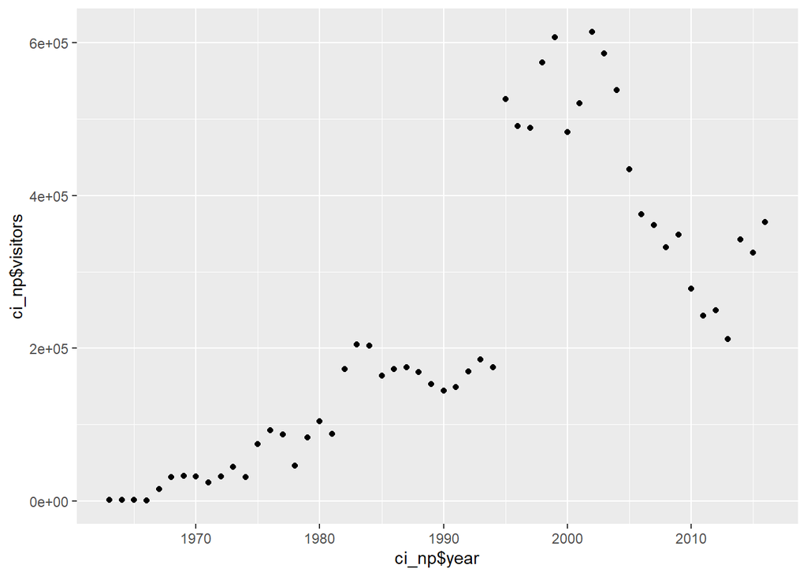

```r
# making base layer for ci_np viz

gg_base <- ggplot(data = ci_np, aes(x = ci_np$year, y = ci_np$visitors))

gg_base + geom_point()
```

### Customization of visualizations

Here we will learn about how to customize elements of the visualizations

We can update: - Line or point colors: color - Change line type: linetype - Change fill: fill

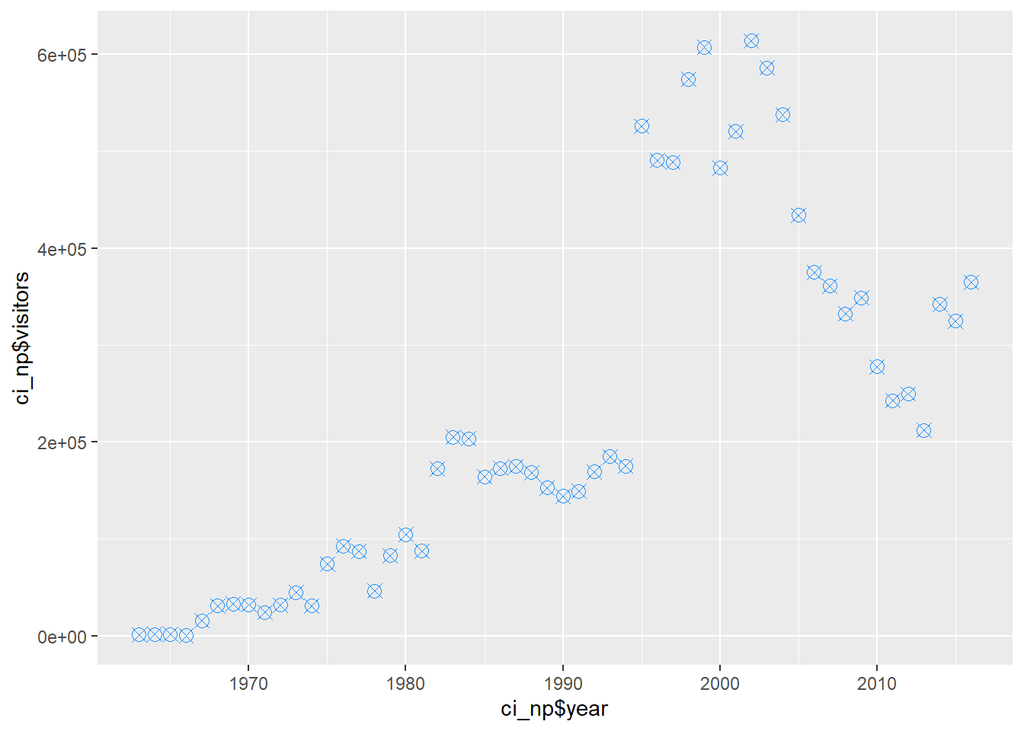

```r
gg_base +
  geom_point(
    color = "dodgerblue",
    pch = 13,
    size = 3

  )
```

```r
# updating based on constants gives the output below
```

[output not shown]

### Update the graph aesthetics based on variables

Here we will create changes based on the continuous variable of **vistors**

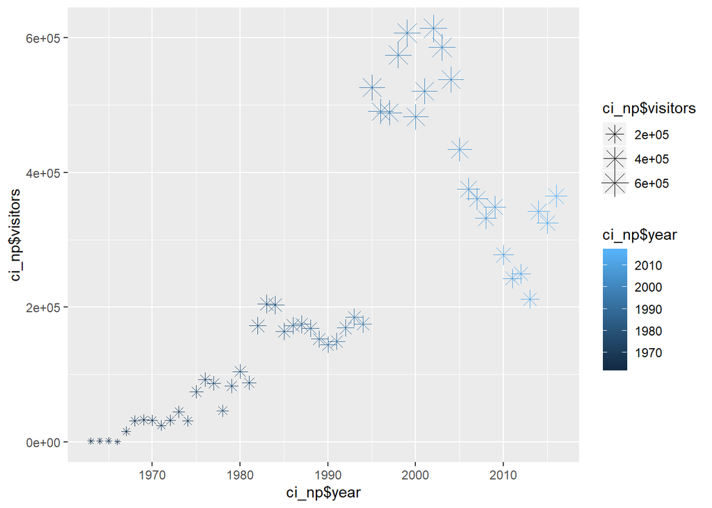

```r
gg_base +
  geom_point(
    aes(size = ci_np$visitors,
        color = ci_np$year),
    pch = 8

  )
```

### Usings themes in ggplot via gg-themes for overall updates

Use the following recommended themes as examples: - theme_light - theme_minimal - theme_bw

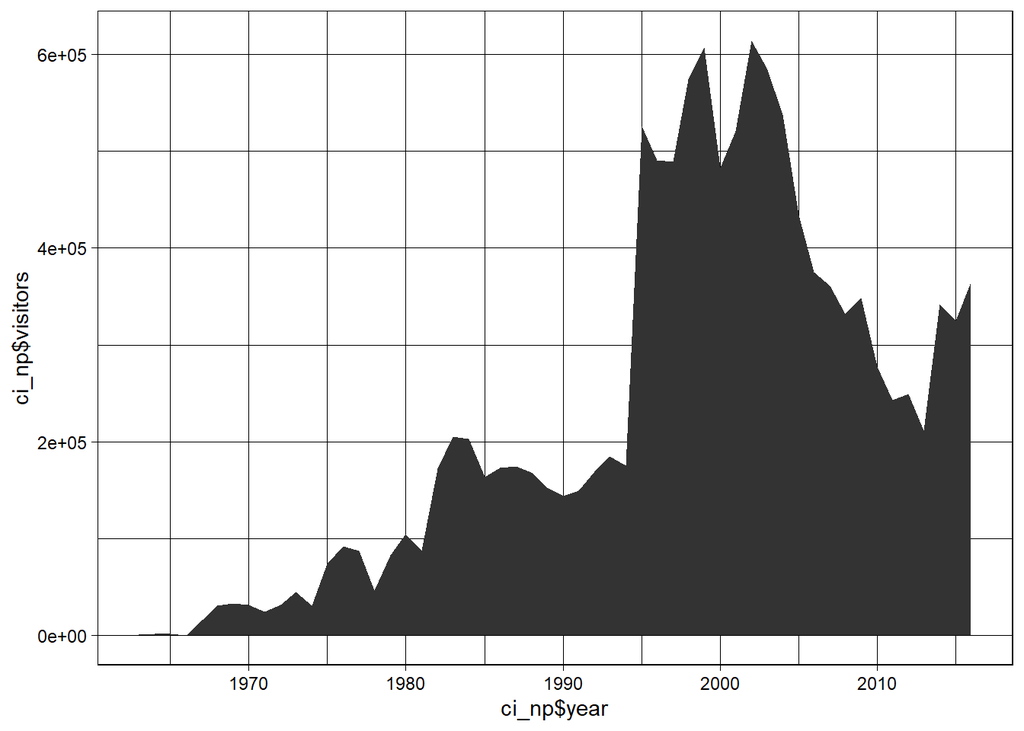

```r
gg_base +
  geom_area() +
  theme_linedraw()
```

### Visualization in series - Moving on to the **ca_np** dataset

Will give ggplot the whole set and let it figure out the breakpoints and the rest

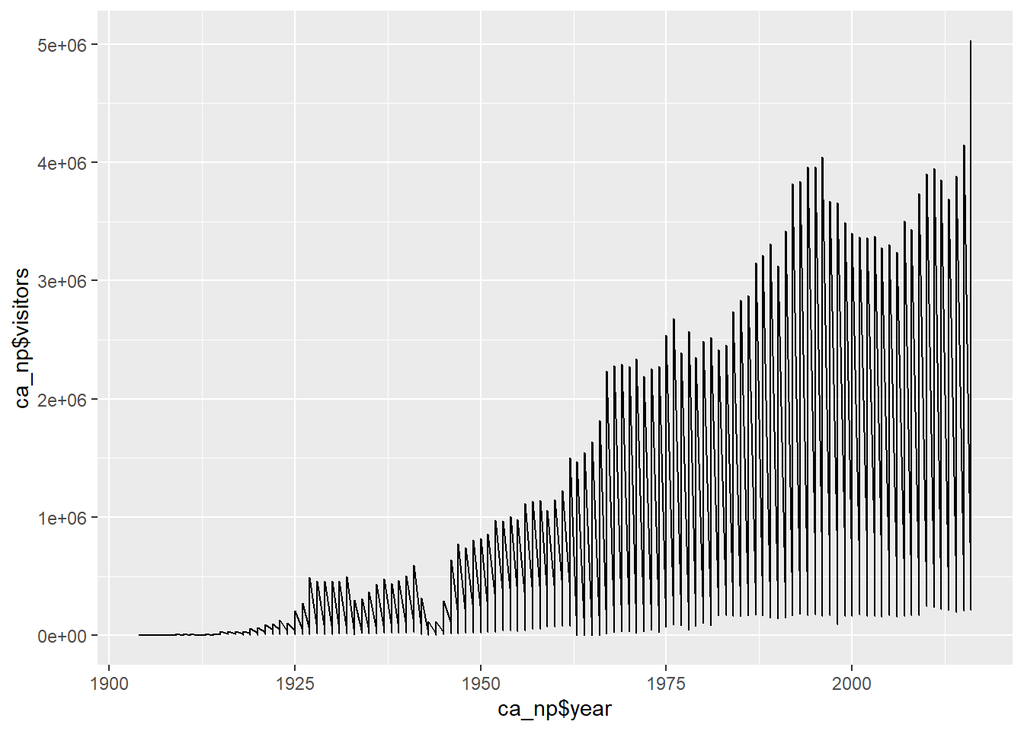

```r
# a bad graph that looks cool -- not respective of the groupings
gg_base2 <- ggplot(data = ca_np, aes(x=ca_np$year, y=ca_np$visitors))

gg_base2 + geom_line()
```

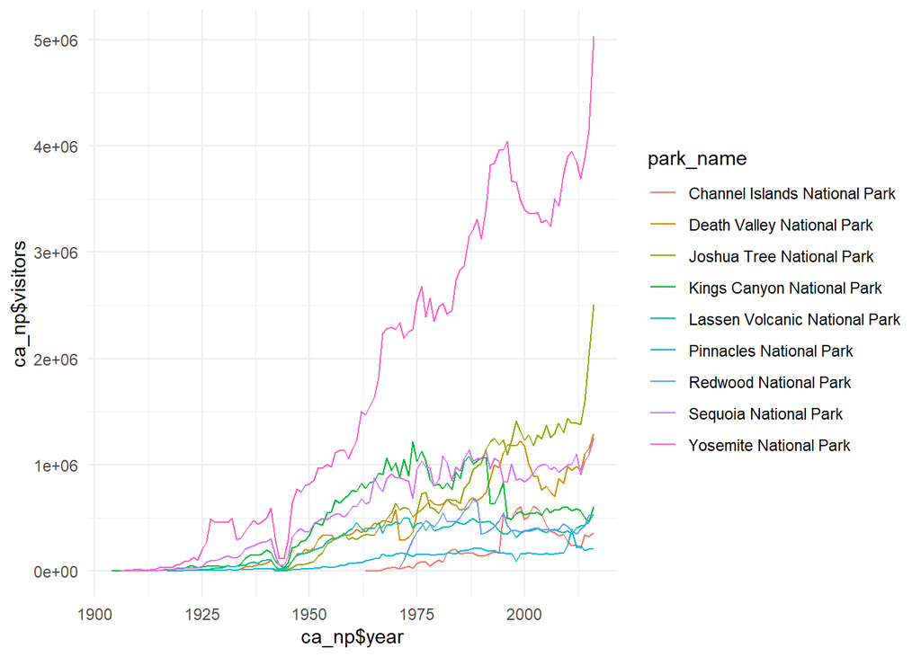

```r
# adding in the group by

gg_base3 <- ggplot(data = ca_np, aes(x=ca_np$year, y=ca_np$visitors, group= park_name))

gg_base3 +
  geom_line( aes(color = park_name) ) +
              theme_minimal()
```

### Faceting via ggplot to break out graphs

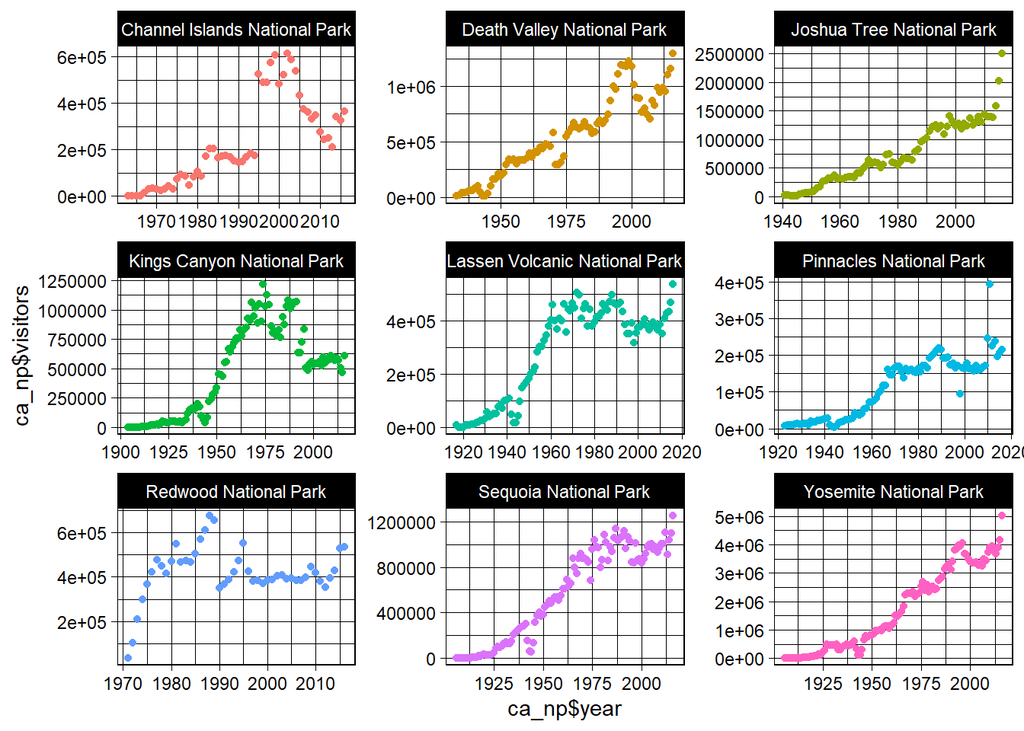

```r
my_np_graph <- gg_base2 +
  geom_point(aes(color =park_name), show.legend = FALSE) +
  facet_wrap(~park_name, scales = "free") +
  theme_linedraw()

#scales default to fixed (all same), so can jailbreak it with 'free'
#legend default to show unless show.lengend= FALSE

my_np_graph
```

### Export my graph as a .png file

```r
ggsave(plot= my_np_graph, here("figures/np_graph1.png"))
```